# filter_by_variant_effect_Mar2017

started: Alexey Larionov, 2016  
last updated: Alexey Larionov, 31Mar2017

# Summary

## Numbers to be corrected after decision about the eigenvector outliers exclusion!

274,037 -> 23,523 variants (10,159 genes, ~2.3 variant per gene)

### Including Loss of function variants

“splice_acceptor_variant”, “splice_donor_variant”, “stop_gain”, “stop_lost”, “start_lost”, “frameshift_variant” : 5,007 variants

### Including dd-missense variants, likely affecting protein function

“deleterious” and “probably_damaging”: 18,050 variants (of 106,983 total missenses)  
add NMD-transcripts?

### Including ClinSig variants

“likely_pathogenic”, “risk_factor”, “pathogenic”, “association”, “protective”, “drug_response”: 842 variants

## NOT excluding variants with high AF in 1k

These are sequence versions from Ref genome, which ALTs are common in 1k:

EUR_AF>0.5: 156 from selected (<1%) EUR_AF>0.9: 28 from selected

These sequences are preserved in this script.  
However, they will need special treatment in downstream analysis.

## NOT excluding multiallelic variaints

604 multiallelic varaints in selected  
(7,178 in the whole variantset)

# start_section

```r
# Start time
Sys.time()
```

```
## [1] "2017-03-31 11:01:40 BST"
```

```r
# Folders
#/analysis/mtgroup_share
#/scratch /medgen
setwd("/analysis/mtgroup_share/scripts/wecare_stat_03.17/scripts")
source_data_folder <- "/analysis/mtgroup_share/scripts/wecare_stat_03.17/source_data"
interim_data_folder <- "/analysis/mtgroup_share/scripts/wecare_stat_03.17/interim_data"
results_folder <- "/analysis/mtgroup_share/scripts/wecare_stat_03.17/results"

# Load libraries
library(dplyr)
```

```r
library(reshape2) # for melt()
library(ggplot2)
library(VennDiagram)
```

# load_data

```r
load(paste(interim_data_folder, "r06_pick_egenvectors_exclude_outliers_Mar2017.RData", sep="/"))
```

# check_data

```r
ls()
```

```
## [1] "interim_data_folder"      "results_folder"
## [3] "source_data_folder"       "wecare_nfe_exac.df"
## [5] "wecare_nfe_genotypes.mx"  "wecare_nfe_kgen.df"
## [7] "wecare_nfe_phenotypes.df" "wecare_nfe_variants.df"
```

```r
dim(wecare_nfe_genotypes.mx)
```

```
## [1] 274037    676
```

```r
class(wecare_nfe_genotypes.mx)
```

```
## [1] "matrix"
```

```r
wecare_nfe_genotypes.mx[1:5,1:5]
```

```
##              HG00097 HG00099 HG00100 HG00102 HG00106
## Var000000002       0       0      NA      NA       0
## Var000000008       0      NA       0       0       0
## Var000000009       0       0       0       0       0
## Var000000012       0       0      NA       0       0
## Var000000013       0       0      NA       0       0
```

```r
dim(wecare_nfe_phenotypes.df)
```

```
## [1] 676  38
```

```r
str(wecare_nfe_phenotypes.df)
```

```
## 'data.frame':    676 obs. of  38 variables:
##  $ wes_id        : chr  "HG00097" "HG00099" "HG00100" "HG00102" ...
##  $ gwas_id       : chr  NA NA NA NA ...
##  $ merged_id     : chr  NA NA NA NA ...
##  $ filter        : chr  "pass" "pass" "pass" "pass" ...
##  $ cc            : num  -1 -1 -1 -1 -1 -1 -1 -1 -1 -1 ...
##  $ setno         : int  NA NA NA NA NA NA NA NA NA NA ...
##  $ registry      : chr  NA NA NA NA ...
##  $ family_history: int  NA NA NA NA NA NA NA NA NA NA ...
##  $ age_dx        : int  NA NA NA NA NA NA NA NA NA NA ...
##  $ age_ref       : num  NA NA NA NA NA NA NA NA NA NA ...
##  $ rstime        : num  NA NA NA NA NA NA NA NA NA NA ...
##  $ eig1_gwas     : num  NA NA NA NA NA NA NA NA NA NA ...
##  $ eig2_gwas     : num  NA NA NA NA NA NA NA NA NA NA ...
##  $ eig3_gwas     : num  NA NA NA NA NA NA NA NA NA NA ...
```

[output cut: 24 more lines]

```r
wecare_nfe_phenotypes.df[1:5,1:5]
```

```
##          wes_id gwas_id merged_id filter cc
## HG00097 HG00097    <NA>      <NA>   pass -1
## HG00099 HG00099    <NA>      <NA>   pass -1
## HG00100 HG00100    <NA>      <NA>   pass -1
## HG00102 HG00102    <NA>      <NA>   pass -1
## HG00106 HG00106    <NA>      <NA>   pass -1
```

```r
dim(wecare_nfe_variants.df)
```

```
## [1] 274037     50
```

```r
colnames(wecare_nfe_variants.df)
```

```
##  [1] "SplitVarID"         "SYMBOL"             "TYPE"
##  [4] "CHROM"              "POS"                "REF"
##  [7] "ALT"                "ac_raw"             "af_raw"
## [10] "an_raw"             "Consequence"        "SIFT_call"
## [13] "SIFT_score"         "PolyPhen_call"      "PolyPhen_score"
## [16] "CLIN_SIG"           "cDNA_position"      "CDS_position"
## [19] "Codons"             "Protein_position"   "Amino_acids"
## [22] "Existing_variation" "Multiallelic"       "ac_all"
## [25] "an_all"             "af_all"             "ac_nfe"
## [28] "an_nfe"             "af_nfe"             "ac_wecare"
## [31] "an_wecare"          "af_wecare"          "ac_ubc"
## [34] "an_ubc"             "af_ubc"             "ac_cbc"
## [37] "an_cbc"             "af_cbc"             "ac_ubc_fam"
## [40] "an_ubc_fam"         "af_ubc_fam"         "ac_ubc_nofam"
## [43] "an_ubc_nofam"       "af_ubc_nofam"       "ac_cbc_fam"
## [46] "an_cbc_fam"         "af_cbc_fam"         "ac_cbc_nofam"
## [49] "an_cbc_nofam"       "af_cbc_nofam"
```

```r
wecare_nfe_variants.df[1:5,1:5]
```

```
##                SplitVarID    SYMBOL  TYPE CHROM    POS
## Var000000002 Var000000002 LINC00115   SNP     1 762330
## Var000000008 Var000000008    SAMD11   SNP     1 871215
## Var000000009 Var000000009    SAMD11   SNP     1 871230
## Var000000012 Var000000012    SAMD11 INDEL     1 874778
## Var000000013 Var000000013    SAMD11   SNP     1 878664
```

```r
dim(wecare_nfe_kgen.df)
```

```
## [1] 274037      9
```

```r
colnames(wecare_nfe_kgen.df)
```

```
## [1] "SplitVarID"  "kgen.AC"     "kgen.AN"     "kgen.AF"     "kgen.AFR_AF"
## [6] "kgen.AMR_AF" "kgen.EAS_AF" "kgen.EUR_AF" "kgen.SAS_AF"
```

```r
wecare_nfe_kgen.df[1:5,1:5]
```

```
##                SplitVarID kgen.AC kgen.AN     kgen.AF kgen.AFR_AF
## Var000000002 Var000000002      NA      NA          NA          NA
## Var000000008 Var000000008      NA      NA          NA          NA
## Var000000009 Var000000009      NA      NA          NA          NA
## Var000000012 Var000000012      NA      NA          NA          NA
## Var000000013 Var000000013       2    5008 0.000399361           0
```

```r
dim(wecare_nfe_exac.df)
```

```
## [1] 274037     48
```

```r
colnames(wecare_nfe_exac.df)
```

```
##  [1] "SplitVarID"              "exac_non_TCGA.AF"
##  [3] "exac_non_TCGA.AC"        "exac_non_TCGA.AN"
##  [5] "exac_non_TCGA.AC_FEMALE" "exac_non_TCGA.AN_FEMALE"
##  [7] "exac_non_TCGA.AC_MALE"   "exac_non_TCGA.AN_MALE"
##  [9] "exac_non_TCGA.AC_Adj"    "exac_non_TCGA.AN_Adj"
## [11] "exac_non_TCGA.AC_Hom"    "exac_non_TCGA.AC_Het"
## [13] "exac_non_TCGA.AC_Hemi"   "exac_non_TCGA.AC_AFR"
## [15] "exac_non_TCGA.AN_AFR"    "exac_non_TCGA.Hom_AFR"
## [17] "exac_non_TCGA.Het_AFR"   "exac_non_TCGA.Hemi_AFR"
## [19] "exac_non_TCGA.AC_AMR"    "exac_non_TCGA.AN_AMR"
## [21] "exac_non_TCGA.Hom_AMR"   "exac_non_TCGA.Het_AMR"
## [23] "exac_non_TCGA.Hemi_AMR"  "exac_non_TCGA.AC_EAS"
## [25] "exac_non_TCGA.AN_EAS"    "exac_non_TCGA.Hom_EAS"
## [27] "exac_non_TCGA.Het_EAS"   "exac_non_TCGA.Hemi_EAS"
## [29] "exac_non_TCGA.AC_FIN"    "exac_non_TCGA.AN_FIN"
## [31] "exac_non_TCGA.Hom_FIN"   "exac_non_TCGA.Het_FIN"
## [33] "exac_non_TCGA.Hemi_FIN"  "exac_non_TCGA.AC_NFE"
## [35] "exac_non_TCGA.AN_NFE"    "exac_non_TCGA.Hom_NFE"
## [37] "exac_non_TCGA.Het_NFE"   "exac_non_TCGA.Hemi_NFE"
## [39] "exac_non_TCGA.AC_SAS"    "exac_non_TCGA.AN_SAS"
## [41] "exac_non_TCGA.Hom_SAS"   "exac_non_TCGA.Het_SAS"
## [43] "exac_non_TCGA.Hemi_SAS"  "exac_non_TCGA.AC_OTH"
## [45] "exac_non_TCGA.AN_OTH"    "exac_non_TCGA.Hom_OTH"
## [47] "exac_non_TCGA.Het_OTH"   "exac_non_TCGA.Hemi_OTH"
```

```r
wecare_nfe_exac.df[1:5,1:5]
```

```
##                SplitVarID exac_non_TCGA.AF exac_non_TCGA.AC
## Var000000002 Var000000002        0.0120000              175
## Var000000008 Var000000008               NA               NA
## Var000000009 Var000000009               NA               NA
## Var000000012 Var000000012               NA               NA
## Var000000013 Var000000013        0.0005838               62
##              exac_non_TCGA.AN exac_non_TCGA.AC_FEMALE
## Var000000002            14012                      59
## Var000000008               NA                      NA
## Var000000009               NA                      NA
## Var000000012               NA                      NA
## Var000000013           106198                      17
```

```r
sum(rownames(wecare_nfe_genotypes.mx) != rownames(wecare_nfe_variants.df))
```

```
## [1] 0
```

```r
sum(rownames(wecare_nfe_genotypes.mx) != rownames(wecare_nfe_kgen.df))
```

```
## [1] 0
```

```r
sum(rownames(wecare_nfe_genotypes.mx) != rownames(wecare_nfe_exac.df))
```

```
## [1] 0
```

```r
sum(colnames(wecare_nfe_genotypes.mx) != rownames(wecare_nfe_phenotypes.df))
```

```
## [1] 0
```

# — explore_variants_annotations —

## VEP_consequences

A combination of the below consequencies can be assigned to a variant  
“incomplete_terminal_codon_variant” added to wecare only

```r
sum(is.na(wecare_nfe_variants.df$Consequence)) # 0
```

```
## [1] 0
```

```r
a <- strsplit(as.vector(wecare_nfe_variants.df$Consequence),"&")
b <- unique(as.vector(unlist(a)))
b
```

```
##  [1] "non_coding_transcript_exon_variant"
##  [2] "non_coding_transcript_variant"
##  [3] "synonymous_variant"
##  [4] "inframe_deletion"
##  [5] "missense_variant"
##  [6] "stop_gained"
##  [7] "splice_region_variant"
##  [8] "intron_variant"
##  [9] "downstream_gene_variant"
## [10] "5_prime_UTR_variant"
## [11] "3_prime_UTR_variant"
## [12] "mature_miRNA_variant"
## [13] "inframe_insertion"
## [14] "upstream_gene_variant"
## [15] "splice_acceptor_variant"
## [16] "frameshift_variant"
## [17] "splice_donor_variant"
## [18] "stop_lost"
## [19] "coding_sequence_variant"
## [20] "stop_retained_variant"
## [21] "intergenic_variant"
## [22] "start_lost"
## [23] "NMD_transcript_variant"
## [24] "incomplete_terminal_codon_variant"
## [25] "protein_altering_variant"
```

```r
rm(a,b)
```

## sift, polyphen

### Annotations seen in wecare-nfe

*SIFT:* “tolerated”, “deleterious”, “tolerated_low_confidence”, “deleterious_low_confidence”

*PolyPhen:* “benign”, “possibly_damaging”, “probably_damaging”, “unknown”

### Interpreting SIFT and PolyPhen scores (not used here)

*SIFT:* the higher score the less deleterious  
*PolyPhen:* the higher score the more damaging

```r
# SIFT
unique(as.vector(wecare_nfe_variants.df$SIFT_call))
```

```
## [1] NA                           "tolerated"
## [3] "deleterious"                "deleterious_low_confidence"
## [5] "tolerated_low_confidence"
```

```r
# PolyPhen
unique(as.vector(wecare_nfe_variants.df$PolyPhen_call))
```

```
## [1] NA                  "benign"            "probably_damaging"
## [4] "possibly_damaging" "unknown"
```

## clin_sig

### Annotations seen in wecare-nfe

*CLIN_SIG:* “likely_benign”, “benign”, “likely_pathogenic”, “risk_factor”, “not_provided”, “uncertain_significance”, “pathogenic”, “association”, “protective”, “other”, “drug_response”

The same as in wecare-only. I have also seen “confers_sensitivity” in CLIN_SIG for gastric cases

```r
unique(unlist(strsplit(as.vector(wecare_nfe_variants.df$CLIN_SIG), split="\\&")))
```

```
##  [1] NA                       "benign"
##  [3] "likely_benign"          "likely_pathogenic"
##  [5] "uncertain_significance" "risk_factor"
##  [7] "not_provided"           "pathogenic"
##  [9] "drug_response"          "association"
## [11] "protective"             "other"
```

## count_variants_frequent_in_kgen_and_exac

Tehy will be preserbved; however they should be treated specially in downstream analyses because “variants” called in these sites represent sequence versions common in humans, despite the misleading “low” MAFs in some databases.

```r
x <- wecare_nfe_kgen.df  %>% filter(kgen.EUR_AF > 0.9) %>% select(SplitVarID) # 2,350
y <- wecare_nfe_exac.df  %>% filter(exac_non_TCGA.AF > 0.9) %>% select(SplitVarID) # 1,728

x <- as.character(x[,1])
y <- as.character(y[,1])
z <- intersect(x,y)

length(x) # 2,369
```

```
## [1] 2369
```

```r
length(y) # 1,744
```

```
## [1] 1744
```

```r
length(z) # 1,627
```

```
## [1] 1627
```

```r
rm(x,y,z)
```

## count_multiallelic_varaints

7,178 multiallelic varaints

```r
summary(wecare_nfe_variants.df$Multiallelic) # 7,178
```

```
##    Mode   FALSE    TRUE    NA's
## logical  266859    7178       0
```

# — Make indices —

## make_lof_index

```r
sum(is.na(wecare_nfe_variants.df$Consequence)) # 0
```

```
## [1] 0
```

```r
# --- Splice acceptor variants (sav) --- #

splice_acceptor_variant <- grepl( "splice_acceptor_variant", wecare_nfe_variants.df$Consequence)
sum(splice_acceptor_variant) # 423
```

```
## [1] 423
```

```r
# mean count of alleles per case in wecare
sav_wecare_nfe.mx <- wecare_nfe_genotypes.mx[splice_acceptor_variant,]
sav_wecare_nfe.counts <- apply(sav_wecare_nfe.mx, 2, sum, na.rm=TRUE)
sav_wecare_nfe.mean <- mean(sav_wecare_nfe.counts, na.rm=TRUE) # ~22
rm(sav_wecare_nfe.mx, sav_wecare_nfe.counts)

# --- Splice donor variants (sdv) --- #

splice_donor_variant <- grepl( "splice_donor_variant", wecare_nfe_variants.df$Consequence)
sum(splice_donor_variant) # 625
```

```
## [1] 625
```

```r
# mean count of alleles per case in wecare
sdv_wecare_nfe.mx <- wecare_nfe_genotypes.mx[splice_donor_variant,]
sdv_wecare_nfe.counts <- apply(sdv_wecare_nfe.mx, 2, sum, na.rm=TRUE)
sdv_wecare_nfe.mean <- mean(sdv_wecare_nfe.counts, na.rm=TRUE) # ~16
rm(sdv_wecare_nfe.mx, sdv_wecare_nfe.counts)

# --- Stop gains --- #

stop_gain <- grepl( "stop_gain", wecare_nfe_variants.df$Consequence)
sum(stop_gain) # 2,189
```

```
## [1] 2189
```

```r
# mean count of alleles per case in wecare
stogv_wecare_nfe.mx <- wecare_nfe_genotypes.mx[stop_gain,]
stogv_wecare_nfe.counts <- apply(stogv_wecare_nfe.mx, 2, sum, na.rm=TRUE)
stogv_wecare_nfe.mean <- mean(stogv_wecare_nfe.counts, na.rm=TRUE) # ~50
rm(stogv_wecare_nfe.mx, stogv_wecare_nfe.counts)

# --- Stop losts --- #

# Interestingly, there are much less of stop_losts than stop_gains: 79 and 2,189 respectively.
# This looks contraintuitive, suggesting that stop_gains are better tolerated than stop losses.
# In other words: stop_losses may be under stronger evolutionary control than stop_gains??

# An alternative explanation coulod be that stop losts can only happen on stop codons;
# while stop gain can happen in "any"" codon within the gene: so stop gains have much more chances to happen.

stop_lost <- grepl( "stop_lost", wecare_nfe_variants.df$Consequence)
sum(stop_lost) # 79
```

```
## [1] 79
```

```r
# mean count of alleles per case in wecare
stolv_wecare_nfe.mx <- wecare_nfe_genotypes.mx[stop_lost,]
stolv_wecare_nfe.counts <- apply(stolv_wecare_nfe.mx, 2, sum, na.rm=TRUE)
stolv_wecare_nfe.mean <- mean(stolv_wecare_nfe.counts, na.rm=TRUE) # ~15
rm(stolv_wecare_nfe.mx, stolv_wecare_nfe.counts)

# --- Start losts --- #

# Functional significance of start losses may be questioned: a heterozigous start loss may
# be easily compemsated by a mere expression of retained allele??

# However, there is not much of them... Either this is an evolutionary control or just "low base" effect (as above for the stop_losses)?

# The total number of start losses is small, so they should not influence the analysis too much anyway ...

# Why there is no such consequence as "Start gain" ?

start_lost <- grepl( "start_lost", wecare_nfe_variants.df$Consequence)
sum(start_lost) # 113
```

```
## [1] 113
```

```r
# mean count of alleles per case in wecare
stalv_wecare_nfe.mx <- wecare_nfe_genotypes.mx[start_lost,]
stalv_wecare_nfe.counts <- apply(stalv_wecare_nfe.mx, 2, sum, na.rm=TRUE)
stalv_wecare_nfe.mean <- mean(stalv_wecare_nfe.counts, na.rm=TRUE) # ~7
rm(stalv_wecare_nfe.mx, stalv_wecare_nfe.counts)

# --- Frameshifts --- #

frameshift_variant <- grepl( "frameshift_variant", wecare_nfe_variants.df$Consequence)
sum(frameshift_variant) # 1,623
```

```
## [1] 1623
```

```r
# mean count of alleles per case in wecare
fsv_wecare_nfe.mx <- wecare_nfe_genotypes.mx[frameshift_variant,]
fsv_wecare_nfe.counts <- apply(fsv_wecare_nfe.mx, 2, sum, na.rm=TRUE)
fsv_wecare_nfe.mean <- mean(fsv_wecare_nfe.counts, na.rm=TRUE) # ~124
rm(fsv_wecare_nfe.mx, fsv_wecare_nfe.counts)

# --- all LoF-s --- #

lof <- splice_acceptor_variant | splice_donor_variant | stop_gain | stop_lost | start_lost | frameshift_variant

sum(lof) # 5,007
```

```
## [1] 5007
```

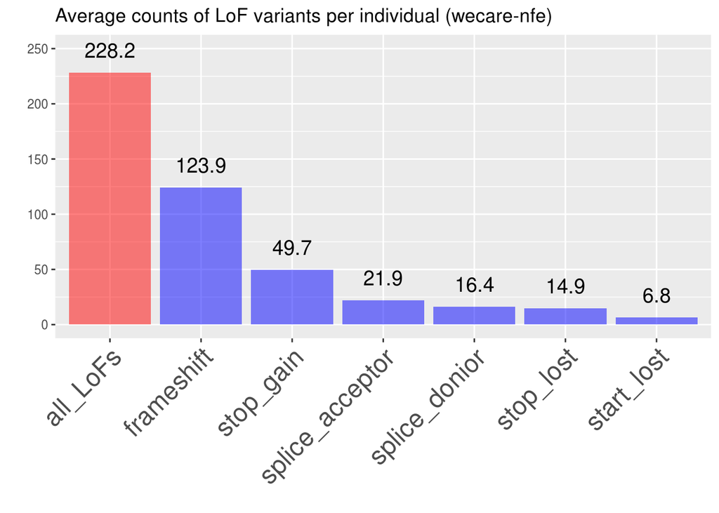

```r
# mean count of alleles per case in wecare
lof_wecare_nfe.mx <- wecare_nfe_genotypes.mx[lof,]
lof_wecare_nfe.counts <- apply(lof_wecare_nfe.mx, 2, sum, na.rm=TRUE)
lof_wecare_nfe.mean <- mean(lof_wecare_nfe.counts, na.rm=TRUE) # ~228
rm(lof_wecare_nfe.mx, lof_wecare_nfe.counts)

# ------- Plot average counts of lof-s per individual ------- #

# Summary table with average numbers of lof-s per individual
lof_summary_counts.df <- as.data.frame(cbind(
  lof_type=c("splice_acceptor", "splice_donior", "stop_gain", "stop_lost", "start_lost", "frameshift", "all_LoFs"),
  lof_count=c(sav_wecare_nfe.mean, sdv_wecare_nfe.mean, stogv_wecare_nfe.mean, stolv_wecare_nfe.mean, stalv_wecare_nfe.mean, fsv_wecare_nfe.mean, lof_wecare_nfe.mean)))

lof_summary_counts.df$lof_count <- as.numeric(as.vector(lof_summary_counts.df$lof_count))
lof_summary_counts.df <- lof_summary_counts.df %>% arrange(desc(lof_count))

# Order of levels defines order of bars on the plot
lof_summary_counts.df$lof_type <- factor(lof_summary_counts.df$lof_type,
  levels=c("all_LoFs", "frameshift", "stop_gain", "splice_acceptor", "splice_donior", "stop_lost", "start_lost"))

# Plot
ggplot(lof_summary_counts.df, aes(lof_type, lof_count)) +
  geom_bar(stat="identity", fill=c("red",rep("blue",6)), alpha=0.5) +
  geom_text(aes(label=round(lof_count,1)), vjust=-1, size=5)+
  labs(x = "", y = "") +
  ylim(0,250) +
  theme(axis.text.x = element_text(hjust=1, size=18, angle=45)) +
  ggtitle("Average counts of LoF variants per individual (wecare-nfe)")
```

```r
# Clean-up
rm(splice_acceptor_variant, splice_donor_variant, stop_gain, frameshift_variant, stop_lost,
   start_lost, sav_wecare_nfe.mean, sdv_wecare_nfe.mean, stogv_wecare_nfe.mean, stolv_wecare_nfe.mean,
   stalv_wecare_nfe.mean, fsv_wecare_nfe.mean, lof_summary_counts.df)
```

## make_missense_index

Selecting dd-missense variants:  
both: [ deleterious by SIFT ] AND [ probably_damaging by PolyPhen ]

```r
missense_all <- grepl( "missense_variant", wecare_nfe_variants.df$Consequence)
sum(missense_all) # 106,983
```

```
## [1] 106983
```

```r
summary(wecare_nfe_variants.df$SIFT_call)
```

```
##                deleterious deleterious_low_confidence
##                      37684                       3387
##                  tolerated   tolerated_low_confidence
##                      52525                       5073
##                       NA's
##                     175368
```

```r
# note many NAs; these are when SIFT is irrelevant (e.g. non-coding)?
deleterious <- wecare_nfe_variants.df$SIFT_call == "deleterious"
summary(deleterious)
```

```
##    Mode   FALSE    TRUE    NA's
## logical   60985   37684  175368
```

```r
FALSE -> deleterious[is.na(deleterious)]
summary(deleterious) # 37,684
```

```
##    Mode   FALSE    TRUE    NA's
## logical  236353   37684       0
```

```r
summary(wecare_nfe_variants.df$PolyPhen_call)
```

```
##            benign possibly_damaging probably_damaging           unknown
##             61900             17080             24570              3089
##              NA's
##            167398
```

```r
# note many NAs; these are when PolyPhen is irrelevant (e.g. non-coding)?
probably_damaging <- wecare_nfe_variants.df$PolyPhen_call == "probably_damaging"
summary(probably_damaging)
```

```
##    Mode   FALSE    TRUE    NA's
## logical   82069   24570  167398
```

```r
FALSE -> probably_damaging[is.na(probably_damaging)]
summary(probably_damaging) # 24,570
```

```
##    Mode   FALSE    TRUE    NA's
## logical  249467   24570       0
```

```r
missense <- deleterious & probably_damaging
sum(missense) # 18,050
```

```
## [1] 18050
```

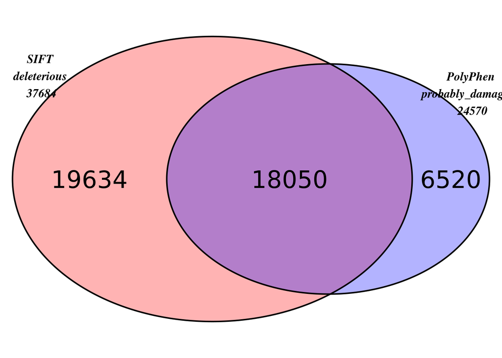

```
## (polygon[GRID.polygon.44], polygon[GRID.polygon.45], polygon[GRID.polygon.46], polygon[GRID.polygon.47], text[GRID.text.48], text[GRID.text.49], text[GRID.text.50], text[GRID.text.51], text[GRID.text.52])
```

```r
# Plot venn diagram of selected variants by types
grid.newpage()
draw.pairwise.venn(
  area1=sum(deleterious),
  area2=sum(probably_damaging),
  cross.area=sum(missense),
  category=c(
    paste("SIFT\ndeleterious\n", sum(deleterious)),
    paste("PolyPhen\nprobably_damaging\n", sum(probably_damaging))),
  fill=c("red", "blue"),
  alpha = c(0.3, 0.3),
  cex=2, cat.fontface=4, fontfamily=3)
```

```r
# mean count of missenses per case in wecare
missense_wecare_nfe.mx <- wecare_nfe_genotypes.mx[missense,]
missense_wecare_nfe.counts <- apply(missense_wecare_nfe.mx, 2, sum, na.rm=TRUE)
missense_wecare_nfe.mean <- mean(missense_wecare_nfe.counts, na.rm=TRUE)
missense_wecare_nfe.mean # ~375
```

```
## [1] 374.7589
```

```r
# Clean-up
rm(missense_all, deleterious, probably_damaging, missense_wecare_nfe.mx, missense_wecare_nfe.counts)
```

## make_clinsig_index

ClinSig version as reported by Ensembl v87-grch37_vep_cache (Jan2017, VEP script) ClinVar may become a better variant-annotation database, which may be used in future.

All *CLIN_SIG* annotations found in the file: “likely_benign”, “benign”, “likely_pathogenic”, “risk_factor”, “not_provided”, “uncertain_significance”, “pathogenic”, “association”, “protective”, “other”, “drug_response”

Note sums w/o na.rm=TRUE.

```r
selected_clinsig_terms <- c("likely_pathogenic", "risk_factor", "pathogenic", "association", "protective", "drug_response")

clinsig <- wecare_nfe_variants.df$CLIN_SIG %in% selected_clinsig_terms
sum(clinsig) # 842
```

```
## [1] 842
```

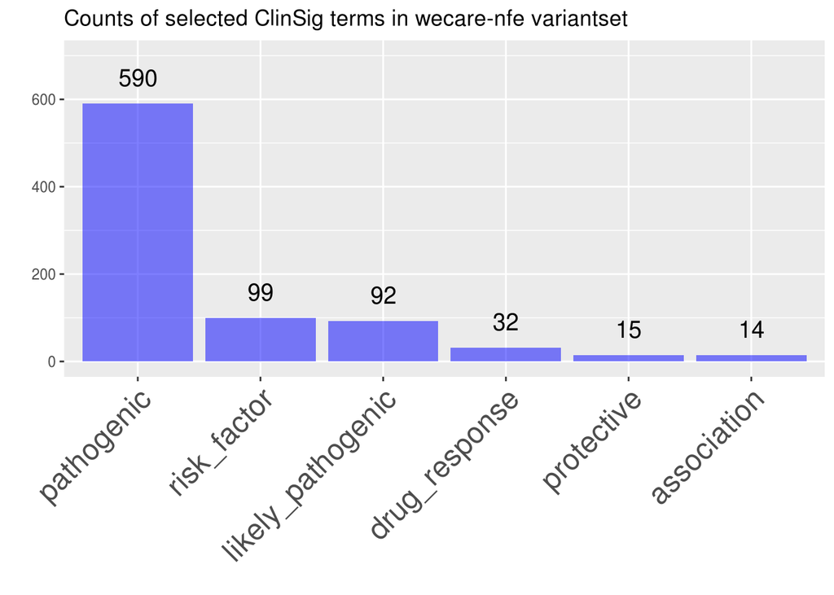

```r
x.df <- as.data.frame(table(as.vector(wecare_nfe_variants.df[clinsig,"CLIN_SIG"])))
c("type","count") -> colnames(x.df)
x.df$type <- factor(x.df$type,
  levels=c("pathogenic", "risk_factor", "likely_pathogenic", "drug_response", "protective", "association"))

ggplot(x.df, aes(type, count)) +
  geom_bar(stat="identity", fill="blue", alpha=0.5) +
  geom_text(aes(label=round(count,1)), vjust=-1, size=5)+
  labs(x = "", y = "") +
  ylim(0,700) +
  theme(axis.text.x = element_text(hjust=1, size=18, angle=45)) +
  ggtitle("Counts of selected ClinSig terms in wecare-nfe variantset")
```

```r
# mean count of alleles per case in wecare
clinsig_wecare_nfe.mx <- wecare_nfe_genotypes.mx[clinsig,]
clinsig_wecare_nfe.counts <- apply(clinsig_wecare_nfe.mx, 2, sum, na.rm=TRUE)
clinsig_wecare_nfe.mean <- mean(clinsig_wecare_nfe.counts, na.rm=TRUE)
clinsig_wecare_nfe.mean # 78.5
```

```
## [1] 78.5
```

```r
# Clean-up
rm(selected_clinsig_terms, clinsig_wecare_nfe.mx, clinsig_wecare_nfe.counts, x.df)
```

# — explore_selected —

## selected_types_per_individual_and_per_variantset

```r
# Count combinations of selectred categories
lof_missense <- lof & missense
clinsig_missense <- clinsig & missense
lof_clinsig <- lof & clinsig
lof_clinsig_missense <- lof_clinsig & missense

summary(lof_missense)
```

```
##    Mode   FALSE    TRUE    NA's
## logical  274023      14       0
```

```r
summary(clinsig_missense)
```

```
##    Mode   FALSE    TRUE    NA's
## logical  273793     244       0
```

```r
summary(lof_clinsig)
```

```
##    Mode   FALSE    TRUE    NA's
## logical  273919     118       0
```

```r
summary(lof_clinsig_missense)
```

```
##    Mode   FALSE    NA's
## logical  274037       0
```

```r
selected_variants <- lof | clinsig | missense

summary(selected_variants) # 23,523
```

```
##    Mode   FALSE    TRUE    NA's
## logical  250514   23523       0
```

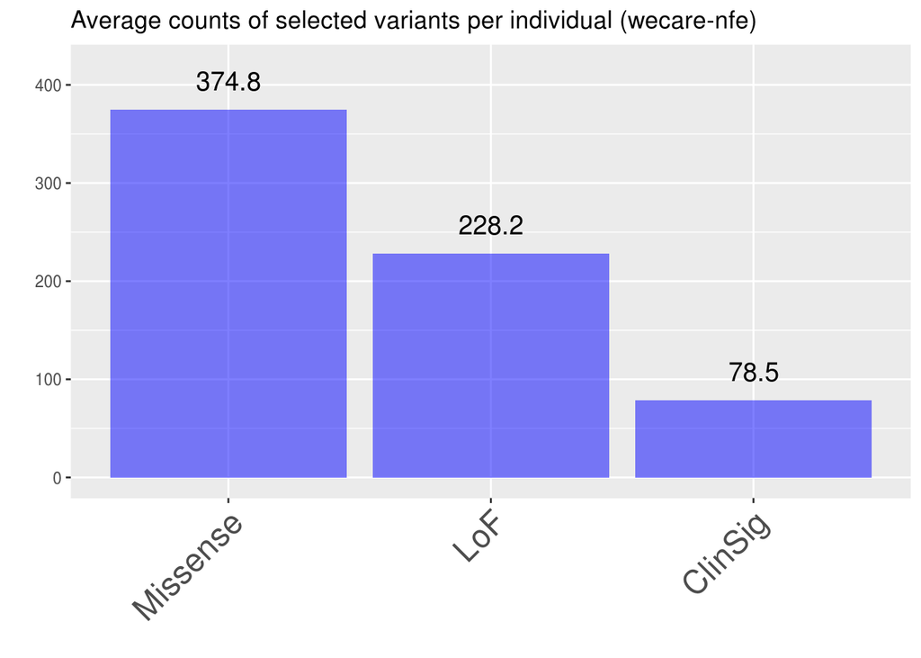

```r
# --- Plot mean counts of variant types per individual --- #

# Summary table with average numbers of protein-affecting per individual
summary_counts.df <- as.data.frame(cbind(
  type=c("Missense", "LoF", "ClinSig"),
  count=c(missense_wecare_nfe.mean, lof_wecare_nfe.mean, clinsig_wecare_nfe.mean)))

# Convert numbers to numeric vector
summary_counts.df$count <- as.numeric(as.vector(summary_counts.df$count))

# Order of levels defines order of bars on the plot
summary_counts.df$type <- factor(summary_counts.df$type,
  levels=c("Missense", "LoF", "ClinSig"))

# Plot bar diagramm of avg. count of selected types per individual
ggplot(summary_counts.df, aes(type, count)) +
  geom_bar(stat="identity", fill="blue", alpha=0.5) +
  geom_text(aes(label=round(count,1)), vjust=-1, size=5)+
  ylim(0, 420) +
  labs(x = "", y = "") +
  theme(axis.text.x = element_text(hjust=1, size=18, angle=45)) +
  ggtitle("Average counts of selected variants per individual (wecare-nfe)")
```

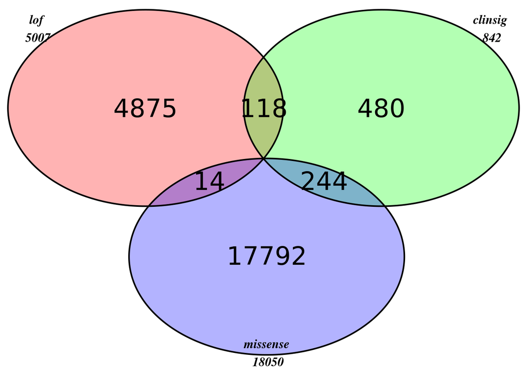

```
## (polygon[GRID.polygon.139], polygon[GRID.polygon.140], polygon[GRID.polygon.141], polygon[GRID.polygon.142], polygon[GRID.polygon.143], polygon[GRID.polygon.144], text[GRID.text.145], text[GRID.text.146], text[GRID.text.147], text[GRID.text.148], text[GRID.text.149], text[GRID.text.150], text[GRI…
```

```r
# Plot venn diagram of selected variants by types
grid.newpage()
draw.triple.venn(
  area1=sum(lof),
  area2=sum(clinsig),
  area3=sum(missense),
  n12=sum(lof_clinsig),
  n23=sum(clinsig_missense),
  n13=sum(lof_missense),
  n123=sum(lof_clinsig_missense),
  category=c(
    paste("lof\n", sum(lof)),
    paste("clinsig\n", sum(clinsig)),
    paste("missense\n", sum(missense))),
  fill = c("red", "green", "blue"),
  alpha = c(0.3, 0.3, 0.3),
  cex=2, cat.fontface=4, fontfamily=3)
```

```r
rm(missense_wecare_nfe.mean, lof_wecare_nfe.mean, clinsig_wecare_nfe.mean,
   lof, clinsig, missense, clinsig_missense, lof_clinsig, lof_missense, lof_clinsig_missense,
   summary_counts.df)
```

# keep_selected_variants_only

```r
wecare_nfe_variants.df <- wecare_nfe_variants.df[selected_variants,]
wecare_nfe_kgen.df <- wecare_nfe_kgen.df[selected_variants,]
wecare_nfe_exac.df <- wecare_nfe_exac.df[selected_variants,]
wecare_nfe_genotypes.mx <- wecare_nfe_genotypes.mx[selected_variants,]


dim(wecare_nfe_variants.df)
```

```
## [1] 23523    50
```

```r
dim(wecare_nfe_kgen.df)
```

```
## [1] 23523     9
```

```r
dim(wecare_nfe_exac.df)
```

```
## [1] 23523    48
```

```r
dim(wecare_nfe_genotypes.mx)
```

```
## [1] 23523   676
```

```r
# Clean-up
rm(selected_variants)
```

# check_frequent_in_Kgen

These variants are preserved; However, they will require special treatment in downstream analysis

```r
x <- wecare_nfe_kgen.df$kgen.EUR_AF > 0.9
FALSE -> x[is.na(x)]
x <- wecare_nfe_kgen.df[x, "SplitVarID"]
x <- as.character(x)
length(x) # 28 variants with AF > 0.9
```

```
## [1] 28
```

```r
wecare_nfe_variants.df[unlist(x),c("SplitVarID","SYMBOL")]
```

```
##                SplitVarID        SYMBOL
## Var000015193 Var000015193           DBT
## Var000015846 Var000015846         PSRC1
## Var000016671 Var000016671        PTPN22
## Var000035434 Var000035434       FAM228B
## Var000049113 Var000049113        METTL8
## Var000055508 Var000055508       STK11IP
## Var000065575 Var000065575       SLC38A3
## Var000086777 Var000086777         ADH1B
## Var000094252 Var000094252       SLC45A2
## Var000097605 Var000097605        SCAMP1
## Var000132581 Var000132581        ZNF117
## Var000132591 Var000132591        ERV3-1
## Var000153820 Var000153820         MROH5
## Var000169838 Var000169838         ITIH5
## Var000180769 Var000180769      PNLIPRP2
## Var000200227 Var000200227         NCAM1
## Var000200228 Var000200228         NCAM1
## Var000230500 Var000230500       HEATR5A
## Var000248712 Var000248712 RP11-114H24.2
## Var000260856 Var000260856          BBS2
## Var000264329 Var000264329       CNTNAP4
## Var000264746 Var000264746        PKD1L2
## Var000271472 Var000271472        PIK3R6
## Var000273808 Var000273808       SLC46A1
## Var000306192 Var000306192        ZNF221
## Var000310251 Var000310251        ZNF534
## Var000322457 Var000322457    AP000244.1
## Var000328275 Var000328275          HPS4
```

```r
y <- wecare_nfe_kgen.df$kgen.EUR_AF > 0.5
sum(y, na.rm=TRUE) # 156 variants with AF > 0.5
```

```
## [1] 156
```

```r
rm(x,y)
```

# count_selected_multiallelic_varaints

604 multiallelics in selected varaints

```r
summary(wecare_nfe_variants.df$Multiallelic) # 604
```

```
##    Mode   FALSE    TRUE    NA's
## logical   22919     604       0
```

# count_variants_per_gene

```r
# Get number of genes
length(unique(wecare_nfe_variants.df$SYMBOL)) # 10,159
```

```
## [1] 10159
```

```r
# Look at the top genes
x <- sort(table(as.vector(wecare_nfe_variants.df$SYMBOL)), decreasing = TRUE)
x[1:200]
```

```
##
##     DNAH3     DNAH7   PDE4DIP    MT-CYB    PKD1L2     TRPM1     DUOX2
##        36        27        22        20        20        19        18
##   IGLV3-1     SPTA1      CUBN    IGSF10      MUC4    MYO18B   PKHD1L1
##        18        18        17        17        17        17        17
##       ATM     C2CD3    COL6A6   IGKV4-1     LAMA1     MYOM2     LAMA2
##        16        16        16        16        16        16        15
##     PKHD1       TNC     ABCA4     ABCC2      DYSF     GFRAL     MKI67
##        15        15        14        14        14        14        14
##      MYH4     MYO7A      NOD2      PLB1      POLG      POLQ    PRUNE2
##        14        14        14        14        14        14        14
##      VWA8      ANK1     CSMD3      LRBA     USP45      UTRN       XDH
##        14        13        13        13        13        13        13
##     ABCA8     CES5A     DCHS2       FN1     LAMA4     MYO1A      NID2
##        12        12        12        12        12        12        12
##      SPTB   TUBGCP6     UGGT2    UMODL1    ZNF568     A2ML1     AGBL1
##        12        12        12        12        12        11        11
##    CCDC66   COL28A1     DOCK8     ECT2L        F5    FER1L6     LAMB2
##        11        11        11        11        11        11        11
##       MPO     MYH13     MYO5C     MYOM1      NAV2    NLRP12      NRAP
##        11        11        11        11        11        11        11
##      OCA2    PDCD11        SI    SPAG17     STAB2        TG    ABCC11
##        11        11        11        11        11        11        10
##       ACE  ADAMTS14  ADAMTSL1     AMPD1     ATP7B     BRCA2   CCDC141
##        10        10        10        10        10        10        10
##    DNASE1     DUOX1       EPX    IQGAP2    KCNJ12       LPA     MCPH1
##        10        10        10        10        10        10        10
##     MYH15      MYOF     NLRP5     PADI4    PLA2R1    PTCHD3      ROS1
##        10        10        10        10        10        10        10
##    SLC3A1    SLC5A4      TEP1     ABCB5  ADAMTS12       AGL   ALDH1B1
##        10        10        10         9         9         9         9
##     ALPK2      ASPM   ATP13A5        C9   CCDC136     CD109    CELSR1
##         9         9         9         9         9         9         9
##      CFTR     CNTLN   CTTNBP2     DAAM2    DNAH14    DOPEY2   EFCAB13
##         9         9         9         9         9         9         9
##      ELP2      EXO1    GPR113     IFIH1  KIAA0556     KRT36     LAMC3
##         9         9         9         9         9         9         9
##      MLH3     MYO5B    NUP188    NUP205     OGDHL       PAH      PASK
##         9         9         9         9         9         9         9
##    PCDH15    PHLPP2     POMT1 RAB11FIP1   RAPGEF3    RSPH4A    SCN10A
##         9         9         9         9         9         9         9
##    SCN11A   SLC10A2   SLC22A1     TEX15  TIMELESS    UNC45B     UTP20
##         9         9         9         9         9         9         9
##       VWF      WFS1    ZNF106    ZNF268    ABCA12     ABCA3     ABCB6
##         9         9         9         9         8         8         8
##    ABCC12   ADAMTS3      ANO2      ATIC    ATP8B3       BLK    CABIN1
##         8         8         8         8         8         8         8
##   CACNA1S     CAPN9     CASC5   CCDC108   CCDC135    CCHCR1      CCR5
##         8         8         8         8         8         8         8
##     CD101   CD163L1      CD36     CDH23    CELSR2    CEP192     CHEK2
##         8         8         8         8         8         8         8
##    CLTCL1     CNTN6   COL15A1       CR2   CYP24A1     DNHD1     EEF2K
##         8         8         8         8         8         8         8
##    EGFLAM    EIF4G1     EXPH5     FANCM     FARP2      FBN3    FRMPD1
##         8         8         8         8         8         8         8
##    GEMIN4     GLIS3      H6PD       HK3  IGHV2-70     INADL     ITGB3
##         8         8         8         8         8         8         8
##     ITIH6  KIAA1217     KRT75     LAMB1
##         8         8         8         8
```

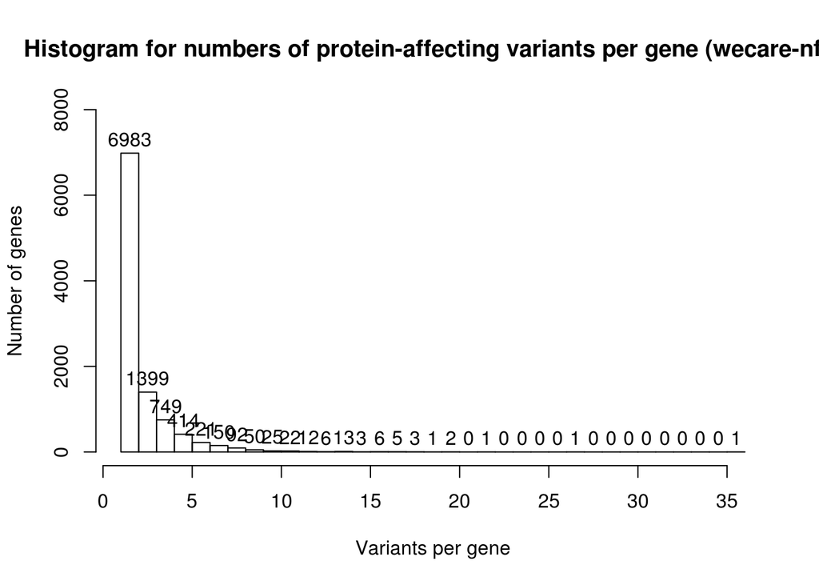

```r
# Save table of counts
y <- cbind(names(x),x)
c("gene","count") -> colnames(y)
write.table(y, file=paste(results_folder, "wecare_nfe_variants_per_gene.txt", sep="/"), quote = FALSE, row.names = FALSE)

# Plot histogram
z <- wecare_nfe_variants.df %>%  group_by(SYMBOL) %>% summarise(n())
"vars_count" -> colnames(z)[2]
hist(z$vars_count, main="Histogram for numbers of protein-affecting variants per gene (wecare-nfe)", xlab="Variants per gene", ylab="Number of genes", ylim=c(0,8000), breaks=36, labels = TRUE)
```

```r
mean(z$vars_count) # 2.315484
```

```
## [1] 2.315484
```

```r
# Clean-up
rm(x,y,z)
```

# explore_AFs_in_selected_variants

```r
mean(wecare_nfe_variants.df$af_all) # ~1.5%
```

```
## [1] 0.01546636
```

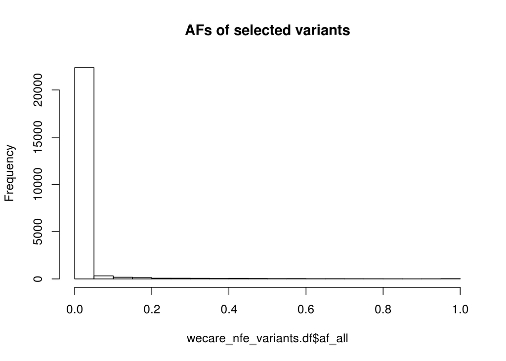

```r
hist(wecare_nfe_variants.df$af_all, main="AFs of selected variants")
```

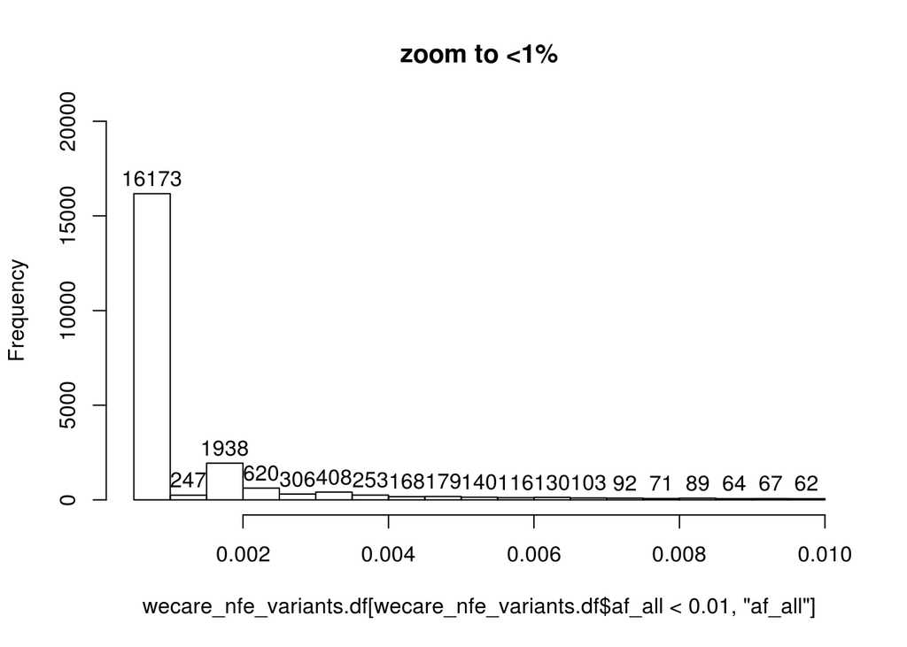

```r
hist(wecare_nfe_variants.df[wecare_nfe_variants.df$af_all<0.01,"af_all"],
     ylim=c(0,20000), labels = TRUE, main="zoom to <1%")
```

# calculate_aggregated_counts_per_gene

```r
# Get list of genes
genes <- unique(as.character(as.vector(wecare_nfe_variants.df$SYMBOL)))

# Make matrix for aggregated counts in wecare-nfe
genes.mx <- matrix(ncol=ncol(wecare_nfe_genotypes.mx),nrow=0)
colnames(genes.mx) <- colnames(wecare_nfe_genotypes.mx)

# Invert genotypes with total AF > 0.5
genotypes_inv.mx <- wecare_nfe_genotypes.mx
for(var in 1:nrow(wecare_nfe_variants.df)){

  if(wecare_nfe_variants.df[var,"af_all"] > 0.5){
    genotype <- wecare_nfe_genotypes.mx[var,]
    inv_genotype <- genotype
    0 -> inv_genotype[genotype == 2]
    2 -> inv_genotype[genotype == 0]
    genotypes_inv.mx[var,] <- inv_genotype
    rm(genotype, inv_genotype)
  }
}

# Calculate counts per gene
for(gene in genes){

  vars <- wecare_nfe_variants.df$SYMBOL == gene

  if(sum(vars)==1){
    counts <- genotypes_inv.mx[vars,] # preserves NA
  }else{
    counts <- apply(genotypes_inv.mx[vars,], 2, sum, na.rm=TRUE)
  }

  genes.mx <- rbind(genes.mx, counts)
  rm(vars,counts)

}

dim(genes.mx)
```

```
## [1] 10159   676
```

```r
counts_per_gene <- apply(genes.mx, 1, sum,na.rm=TRUE)
genes -> names(counts_per_gene)

wecare_nfe_genes.df <- data.frame(genes, counts_per_gene)
wecare_nfe_genes.df$genes <- as.character(as.vector(wecare_nfe_genes.df$genes))
rownames(wecare_nfe_genes.df) <- genes
str(wecare_nfe_genes.df)
```

```
## 'data.frame':    10159 obs. of  2 variables:
##  $ genes          : chr  "NOC2L" "KLHL17" "AGRN" "TTLL10" ...
##  $ counts_per_gene: num  4 3 147 2 2 1 1 1 2 59 ...
```

```r
wecare_nfe_genes.df[wecare_nfe_genes.df$genes=="ATM",]
```

```
##     genes counts_per_gene
## ATM   ATM              28
```

```r
wecare_nfe_genes.df[wecare_nfe_genes.df$genes=="CHEK2",]
```

```
##       genes counts_per_gene
## CHEK2 CHEK2              15
```

```r
# Genes with frequent protein-affecting variants
x <- counts_per_gene[order(-counts_per_gene)]
x[1:100]
```

```
##   PDE4DIP    PKD1L2     CELA1   TAS2R38      NAT2     PRIM2    OR11H6
##      2798      2157      2033      1786      1578      1542      1304
##      SRA1    PTCHD3  HLA-DRB1      RHBG     GSDMB  KIAA0040    PRSS48
##      1278      1221      1159      1130      1121      1069      1068
##     OR2J1     SMYD4     OR1B1 KRTAP10-1     WDR72    CCHCR1     OR4X1
##      1059      1015      1012       934       918       905       898
##  KIAA0753     EXPH5   EFCAB13     ACOT4       PZP  C11orf40    OR51I2
##       888       884       869       862       859       858       851
##     KRT72      IDO2    MS4A14    ZNF568    OR13C5     STOX1  SIGLEC12
##       850       825       811       809       801       798       774
##   DEFB126    SPAG17    ERV3-1  IGLV3-22   TRBV3-1    PKD1L1       PPL
##       772       771       761       761       754       745       744
##     ALPK2    GPRC6A   ANKRD33     TPCN2     MUC3A    OR10X1     OR2G2
##       744       730       726       720       719       706       702
##    OR51B6      INMT    GPRIN1     OR1I1     KRT77   ATP13A5  TRBV10-1
##       701       698       689       687       685       684       684
##     GSDMC    ZNF404     MCPH1      MUC4    KCNJ12    CHMP4A     KLKB1
##       683       683       681       675       674       672       668
##       CD5    CCDC66    NIPAL2   C5orf20   CCDC129     HTR3D     SUMO4
##       663       662       662       660       655       653       652
##     APOL4      IL24     PLCL1      LRMP    ZNF880     NLRP1      MTRR
##       651       650       650       650       650       647       646
##    CLECL1    CYP2A7 KRTAP13-2 SERPINB11     MOB3C   TMEM244      MYPN
##       644       644       643       641       640       640       639
##      CHIA     KRT78     NPSR1    MAP2K3     PLBD1     OR6S1     OR8S1
##       638       637       634       633       632       627       625
##    CCDC65     OR2T4    ZNF626     ABCB1     DCHS2  SLC22A10     P2RX7
##       624       621       621       620       619       618       617
##   MAGEB16     DNAH3
##       617       614
```

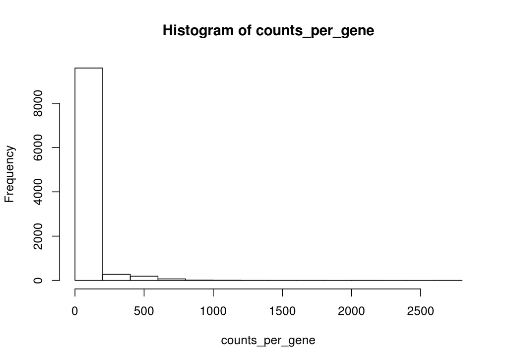

```r
hist(counts_per_gene)
```

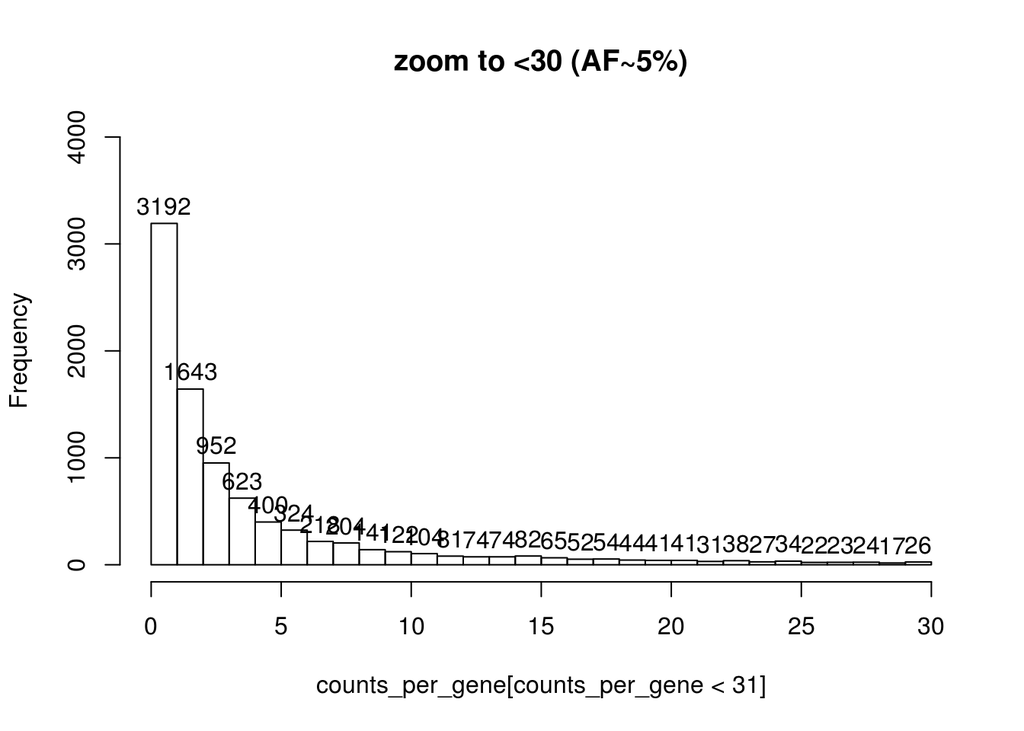

```
##  [1] 3192 1643  952  623  400  324  218  204  141  122  104   81   74   74
## [15]   82   65   52   54   44   41   41   31   38   27   34   22   23   24
## [29]   17   26
```

```r
hist(counts_per_gene[counts_per_gene<31], breaks=c(0:30),
     labels = TRUE, ylim=c(0,4000), main="zoom to <30 (AF~5%)")$counts
```

```r
# Counts >30 (~5%) - too common to be pathogenic
sum(counts_per_gene > 30) # 1,386 - include anyway ?
```

```
## [1] 1386
```

```r
# Counts <3 (~0.5%) - too rare for detection
sum(counts_per_gene < 3) # 4,835
```

```
## [1] 4835
```

```r
# Genes that may be analysed
sum(counts_per_gene >= 3 & counts_per_gene <= 30) # 3,938
```

```
## [1] 3938
```

```r
# Clean-up
rm(genes.mx, genes, gene, genotypes_inv.mx, counts_per_gene, var, x)
```

# data_summary

```r
dim(wecare_nfe_genotypes.mx)
```

```
## [1] 23523   676
```

```r
class(wecare_nfe_genotypes.mx)
```

```
## [1] "matrix"
```

```r
wecare_nfe_genotypes.mx[1:5,1:5]
```

```
##              HG00097 HG00099 HG00100 HG00102 HG00106
## Var000000026       0       0       0       0       0
## Var000000029       0       0       0       0       0
## Var000000031       0       0       0       0       0
## Var000000053       0       0       0       0       0
## Var000000064      NA       0       0       0       0
```

```r
dim(wecare_nfe_genes.df)
```

```
## [1] 10159     2
```

```r
class(wecare_nfe_genes.df)
```

```
## [1] "data.frame"
```

```r
wecare_nfe_genes.df[1:5,]
```

```
##         genes counts_per_gene
## NOC2L   NOC2L               4
## KLHL17 KLHL17               3
## AGRN     AGRN             147
## TTLL10 TTLL10               2
## ACAP3   ACAP3               2
```

```r
dim(wecare_nfe_kgen.df)
```

```
## [1] 23523     9
```

```r
colnames(wecare_nfe_kgen.df)
```

```
## [1] "SplitVarID"  "kgen.AC"     "kgen.AN"     "kgen.AF"     "kgen.AFR_AF"
## [6] "kgen.AMR_AF" "kgen.EAS_AF" "kgen.EUR_AF" "kgen.SAS_AF"
```

```r
wecare_nfe_kgen.df[1:5,1:5]
```

```
##                SplitVarID kgen.AC kgen.AN     kgen.AF kgen.AFR_AF
## Var000000026 Var000000026      NA      NA          NA          NA
## Var000000029 Var000000029       1    5008 0.000199681           0
## Var000000031 Var000000031       1    5008 0.000199681           0
## Var000000053 Var000000053      NA      NA          NA          NA
## Var000000064 Var000000064      NA      NA          NA          NA
```

```r
dim(wecare_nfe_exac.df)
```

```
## [1] 23523    48
```

```r
colnames(wecare_nfe_exac.df)
```

```
##  [1] "SplitVarID"              "exac_non_TCGA.AF"
##  [3] "exac_non_TCGA.AC"        "exac_non_TCGA.AN"
##  [5] "exac_non_TCGA.AC_FEMALE" "exac_non_TCGA.AN_FEMALE"
##  [7] "exac_non_TCGA.AC_MALE"   "exac_non_TCGA.AN_MALE"
##  [9] "exac_non_TCGA.AC_Adj"    "exac_non_TCGA.AN_Adj"
## [11] "exac_non_TCGA.AC_Hom"    "exac_non_TCGA.AC_Het"
## [13] "exac_non_TCGA.AC_Hemi"   "exac_non_TCGA.AC_AFR"
## [15] "exac_non_TCGA.AN_AFR"    "exac_non_TCGA.Hom_AFR"
## [17] "exac_non_TCGA.Het_AFR"   "exac_non_TCGA.Hemi_AFR"
## [19] "exac_non_TCGA.AC_AMR"    "exac_non_TCGA.AN_AMR"
## [21] "exac_non_TCGA.Hom_AMR"   "exac_non_TCGA.Het_AMR"
## [23] "exac_non_TCGA.Hemi_AMR"  "exac_non_TCGA.AC_EAS"
## [25] "exac_non_TCGA.AN_EAS"    "exac_non_TCGA.Hom_EAS"
## [27] "exac_non_TCGA.Het_EAS"   "exac_non_TCGA.Hemi_EAS"
## [29] "exac_non_TCGA.AC_FIN"    "exac_non_TCGA.AN_FIN"
## [31] "exac_non_TCGA.Hom_FIN"   "exac_non_TCGA.Het_FIN"
## [33] "exac_non_TCGA.Hemi_FIN"  "exac_non_TCGA.AC_NFE"
## [35] "exac_non_TCGA.AN_NFE"    "exac_non_TCGA.Hom_NFE"
## [37] "exac_non_TCGA.Het_NFE"   "exac_non_TCGA.Hemi_NFE"
## [39] "exac_non_TCGA.AC_SAS"    "exac_non_TCGA.AN_SAS"
## [41] "exac_non_TCGA.Hom_SAS"   "exac_non_TCGA.Het_SAS"
## [43] "exac_non_TCGA.Hemi_SAS"  "exac_non_TCGA.AC_OTH"
## [45] "exac_non_TCGA.AN_OTH"    "exac_non_TCGA.Hom_OTH"
## [47] "exac_non_TCGA.Het_OTH"   "exac_non_TCGA.Hemi_OTH"
```

```r
wecare_nfe_exac.df[1:5,1:5]
```

```
##                SplitVarID exac_non_TCGA.AF exac_non_TCGA.AC
## Var000000026 Var000000026               NA               NA
## Var000000029 Var000000029        1.506e-04               16
## Var000000031 Var000000031        2.354e-04               25
## Var000000053 Var000000053        1.883e-05                2
## Var000000064 Var000000064        9.416e-06                1
##              exac_non_TCGA.AN exac_non_TCGA.AC_FEMALE
## Var000000026               NA                      NA
## Var000000029           106210                       8
## Var000000031           106210                       4
## Var000000053           106210                       0
## Var000000064           106206                       0
```

```r
dim(wecare_nfe_variants.df)
```

```
## [1] 23523    50
```

```r
str(wecare_nfe_variants.df)
```

```
## 'data.frame':    23523 obs. of  50 variables:
##  $ SplitVarID        : Factor w/ 343824 levels "Var000000001",..: 26 29 31 53 64 65 167 191 227 237 ...
##  $ SYMBOL            : Factor w/ 19862 levels "A1BG","A1CF",..: 11149 11149 11149 8665 8665 8665 540 540 540 540 ...
##  $ TYPE              : Factor w/ 2 levels "INDEL","SNP": 2 2 2 2 2 2 2 2 2 2 ...
##  $ CHROM             : Factor w/ 25 levels "1","10","11",..: 1 1 1 1 1 1 1 1 1 1 ...
##  $ POS               : int  881871 883883 883946 897287 897792 897802 979748 982844 987173 989899 ...
##  $ REF               : Factor w/ 2142 levels "A","AAAAAAAAAAAAAAAAAAAAAAAG",..: 1044 1575 539 539 539 1575 1 1044 1575 539 ...
##  $ ALT               : Factor w/ 1297 levels "A","AAAAAAAAAAAAACT",..: 1 323 989 989 989 664 989 323 664 989 ...
##  $ ac_raw            : int  1 2 1 1 1 1 53 106 1 1 ...
##  $ af_raw            : num  0.000711 0.001555 0.000774 0.000711 0.000722 ...
##  $ an_raw            : int  1406 1286 1292 1406 1386 1390 1416 1388 1420 1414 ...
##  $ Consequence       : Factor w/ 78 levels "3_prime_UTR_variant",..: 66 28 28 28 66 28 28 24 28 28 ...
##  $ SIFT_call         : Factor w/ 4 levels "deleterious",..: NA 1 1 1 NA 1 1 NA 1 1 ...
##  $ SIFT_score        : num  NA 0 0.01 0.04 NA 0 0.01 NA 0 0.02 ...
##  $ PolyPhen_call     : Factor w/ 4 levels "benign","possibly_damaging",..: NA 3 3 3 NA 3 3 NA 3 3 ...
```

[output cut: 36 more lines]

```r
wecare_nfe_variants.df[1:5,1:5]
```

```
##                SplitVarID SYMBOL TYPE CHROM    POS
## Var000000026 Var000000026  NOC2L  SNP     1 881871
## Var000000029 Var000000029  NOC2L  SNP     1 883883
## Var000000031 Var000000031  NOC2L  SNP     1 883946
## Var000000053 Var000000053 KLHL17  SNP     1 897287
## Var000000064 Var000000064 KLHL17  SNP     1 897792
```

```r
dim(wecare_nfe_phenotypes.df)
```

```
## [1] 676  38
```

```r
str(wecare_nfe_phenotypes.df)
```

```
## 'data.frame':    676 obs. of  38 variables:
##  $ wes_id        : chr  "HG00097" "HG00099" "HG00100" "HG00102" ...
##  $ gwas_id       : chr  NA NA NA NA ...
##  $ merged_id     : chr  NA NA NA NA ...
##  $ filter        : chr  "pass" "pass" "pass" "pass" ...
##  $ cc            : num  -1 -1 -1 -1 -1 -1 -1 -1 -1 -1 ...
##  $ setno         : int  NA NA NA NA NA NA NA NA NA NA ...
##  $ registry      : chr  NA NA NA NA ...
##  $ family_history: int  NA NA NA NA NA NA NA NA NA NA ...
##  $ age_dx        : int  NA NA NA NA NA NA NA NA NA NA ...
##  $ age_ref       : num  NA NA NA NA NA NA NA NA NA NA ...
##  $ rstime        : num  NA NA NA NA NA NA NA NA NA NA ...
##  $ eig1_gwas     : num  NA NA NA NA NA NA NA NA NA NA ...
##  $ eig2_gwas     : num  NA NA NA NA NA NA NA NA NA NA ...
##  $ eig3_gwas     : num  NA NA NA NA NA NA NA NA NA NA ...
```

[output cut: 24 more lines]

```r
wecare_nfe_phenotypes.df[1:5,1:5]
```

```
##          wes_id gwas_id merged_id filter cc
## HG00097 HG00097    <NA>      <NA>   pass -1
## HG00099 HG00099    <NA>      <NA>   pass -1
## HG00100 HG00100    <NA>      <NA>   pass -1
## HG00102 HG00102    <NA>      <NA>   pass -1
## HG00106 HG00106    <NA>      <NA>   pass -1
```

```r
# Check consistency of rownames and colnames
sum(colnames(wecare_nfe_genotypes.mx) != rownames(wecare_nfe_phenotypes.df))
```

```
## [1] 0
```

```r
sum(rownames(wecare_nfe_genotypes.mx) != rownames(wecare_nfe_kgen.df))
```

```
## [1] 0
```

```r
sum(rownames(wecare_nfe_genotypes.mx) != rownames(wecare_nfe_exac.df))
```

```
## [1] 0
```

```r
sum(rownames(wecare_nfe_genotypes.mx) != rownames(wecare_nfe_variants.df))
```

```
## [1] 0
```

# save_data

```r
save.image(paste(interim_data_folder, "s07_filter_by_variant_effect_Mar2017.RData", sep="/"))
```

# final_section

```r
ls()
```

```
## [1] "interim_data_folder"      "results_folder"
## [3] "source_data_folder"       "wecare_nfe_exac.df"
## [5] "wecare_nfe_genes.df"      "wecare_nfe_genotypes.mx"
## [7] "wecare_nfe_kgen.df"       "wecare_nfe_phenotypes.df"
## [9] "wecare_nfe_variants.df"
```

```r
Sys.time()
```

```
## [1] "2017-03-31 11:31:52 BST"
```